# MScA, Statistical Analysis (31007) Week 1: Workshop Comparison of Correlations

© Yuri Balasanov, iLykei 2016

**This project will help understanding how correlation works**.

**This project is individual**

## Comparison of correlations

Generate a linear model
$$Y = aX + b + \epsilon,$$

where a and b are constant slope and constant intercept, correspondingly; X is a random variable with variance V[X], $\epsilon$ is a random variable with zero mean and variance $V[\epsilon]$.

Here is how a pair of X and Y can be generated, given the parameters

```r
# Case 1
case1.varianceX<-.1
case1.varianceEps<-6
case1.slopeA<-2
case1.interceptB<-1
case1.sampleX<-rnorm(500,mean=0,sd=sqrt(case1.varianceX))
case1.sampleEps<-rnorm(500,mean=0,sd=sqrt(case1.varianceEps))
case1.sampleY<-case1.slopeA*case1.sampleX+case1.interceptB+case1.sampleEps
```

Cases 2, 3, 4 are simulated similarly.

You have the pairs of sampleX and sampleY for four different cases.

Reading the data

Assign to variable `datapath' the path to your local folder where you saved the data file`Week1_Correlation_Comparison_Project_Data.csv`.  
It should look like:

```r
datapath<-"C:/Your path"
```

where “Your path” is the path to the folder.  
Note that in R path is specified with forward slash “/”. Do not end the path with `/` when you assign `datapath`.

```r
Correlation.Data<-read.csv(file=paste(datapath,'Week1_Correlation_Comparison_Project_Data.csv',sep='/'),
                           header=TRUE,sep=",")
Correlation.Data[1:10,]
```

```
##        Case1.X    Case1.Y     Case2.X    Case2.Y    Case3.X   Case3.Y
## 1   0.58399627  4.0199633  0.92224174  1.5770691  0.1494699 0.9676458
## 2   0.66670633  4.1021954  0.86560707  2.8052322 -0.5711502 0.7373498
## 3  -0.33764324 -1.2829876 -0.09987064 -0.2799140 -0.1078323 0.8854865
## 4  -0.20257654  0.2874005  0.11612037  0.2406017  0.5797361 1.1376463
## 5   0.23739597  3.2780946  0.46538791  1.7969339 -0.3255394 0.9778736
## 6  -0.04764180  1.3629128 -1.03336181  1.3580506 -0.1818759 1.0711811
## 7   0.21280225  0.1236504  0.06318228  0.6117524  0.7011641 1.3365223
## 8   0.01586232 -0.1537856 -1.50206160  0.3527084  0.1105885 1.1313203
## 9   0.32106572  5.6633617 -0.24844314  2.3321448  0.4961246 1.1654568
## 10 -0.11186404 -3.3543425 -0.60624610 -1.1111540 -0.1969617 0.9756164
##       Case4.X   Case4.Y
## 1  -0.8604739 1.0943042
## 2   0.9740597 0.9380182
## 3   0.3570617 0.6422323
## 4   1.5689994 1.4432256
## 5  -1.9253216 0.8432151
## 6   2.5890550 1.2084046
## 7   1.1817209 1.1101272
## 8   1.3015706 0.8169282
## 9  -1.2608939 0.6798103
## 10 -0.1020318 0.9644807
```

Plot the simulated pairs of samples:

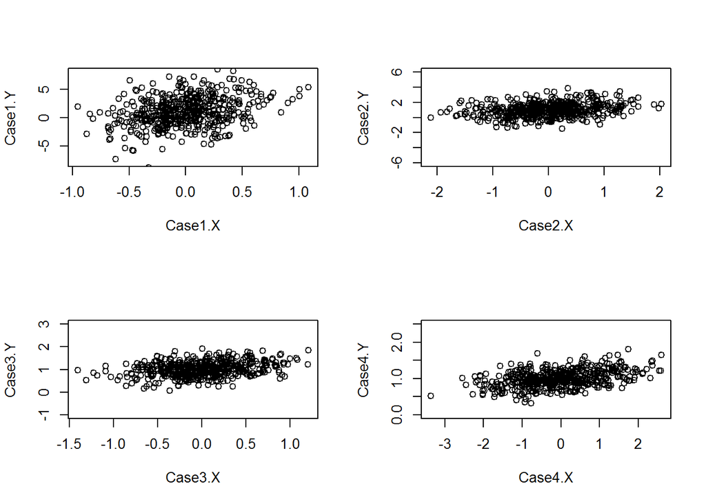

```r
par(mfrow=c(2,2))
with (Correlation.Data,{
      plot(Case1.X,Case1.Y,ylim=c(-8,8))
      plot(Case2.X,Case2.Y,ylim=c(-6,6))
      plot(Case3.X,Case3.Y,ylim=c(-1,3))
      plot(Case4.X,Case4.Y,ylim=c(0,2.5))
})
```

```r
par(mfrow=c(1,1))
```

Calculate sample correlations and determination coefficients.

```r
with(Correlation.Data,{
  Correlation.Case1<-cor(Case1.X,Case1.Y)
  Correlation.Case2<-cor(Case2.X,Case2.Y)
  Correlation.Case3<-cor(Case3.X,Case3.Y)
  Correlation.Case4<-cor(Case4.X,Case4.Y)
  rbind(cbind(Correlation.Case1,Correlation.Case2,Correlation.Case3,Correlation.Case4),
        cbind(Correlation.Case1^2,Correlation.Case2^2,Correlation.Case3^2,Correlation.Case4^2))
})
```

```
##      Correlation.Case1 Correlation.Case2 Correlation.Case3
## [1,]        0.30714119        0.27883620         0.2986515
## [2,]        0.09433571        0.07774963         0.0891927
##      Correlation.Case4
## [1,]         0.4168832
## [2,]         0.1737916
```

## Test. Relationship between slope and correlation

It is a common misconception that slope $a$ of simple linear regression is completely defined by the correlation coefficient $\rho(X,Y)$ between the output $Y$ and predictor $X$ in
$$Y=aX+b+\epsilon.$$

Find how standard deviations of $X$ and $Y$ affect slope $a$ of the model.  
**Hint**. Review [Math Challenge video](http://ilykei.com/api/fileProxy/documents%2FMathChallenge%2FMathChallengeDeterminationCoefficient.mp4).

In the interactive part of the test select manually:

- Standard deviation of input variable $X$ `sdX`
- Standard deviation of output variable $Y$ `sdY`
- Correlation coefficient of $X$ and $Y$ `cXY`

so that the regression line (red) fits the data.

Then keep the correlation coefficient the same and change both standard deviations, so that the line still fits the data.

Observe how different pairs of standard deviations combined with the same correlation coefficient make the same model slope.

Then follow instructions on Description tab to complete the test project.

[interactive chart not shown]